# Relatório 02 - Como usar o projeto Relatórios

Ana Bárbara Andrade Mól

29/04/2022

# 1 Objetivo

Descrição de como escrever o relatório.

# 2 Apresentação do relatório

Passos para a realização do relatório.

## 2.1 Uso do Git

### 2.1.1 Definição e características

- Git é o sistema de controle de versão open source mais usado no mundo atualmente. Ele é usado para controlar o histórico de alterações de arquivos e principalmente de projetos de desenvolvimento de software. Ele permite mais flexibilidade no fluxo de trabalho, segurança e desempenho.
- O Git pode ser usado em todo e qualquer projeto que tenha arquivos de diferentes tipos, podendo ser código, texto, imagens, vídeos, áudios, entre outros.

### 2.1.2 Instalação do Git

- O software Git pode ser baixado através do link: [Git](https://git-scm.com/downloads)

### 2.1.3 Criação de conta no GitHub

- É necessária a criação de uma conta no GitHub para que em seguida criemos um repositório onde será alocado os relatórios. Para isso, basta acessar o link [Login GitHub](https://github.com/login)

## 2.2 Repositório

- Um repositório contém todos os arquivos do projeto e o histórico de revisão de cada arquivo. Local onde é possível gerenciar o trabalho do projeto dentro do repositório.

### 2.2.1 Clonando o repositório do GitHub ao RStudio

- Segue os passos:
- **Passo 1:** RStudio > Tools > Global Options > Terminal > General > Shell > New Terminal open with: Git Bash.
- **Passo 2:** Crie um repositório com o nome: github.io, e caso ja exista com esse nome, use “discestcomp”.

[figure not shown]

Criando repositório

- **Passo 3 :** Após a criação do repositório no GitHub, vá em *Code* e copie o HTTPS.

[figure not shown]

Copiando Code HTML

- **Passo 4:** Agora deverá clonar o repositório ao Rstudio. Para isto, basta acessar:
  - File > New Project… > Version Control > Git > Repository URL > insira o https do repositório Git
  - Escolha em seu computador um diretório em que será salvo o repositório, clicando em: *Create project as subdirectory of*

## 2.3 Uso dos pacotes já instalados

- Os pacotes instalados serão utilizados nos momentos de produção dos relatórios, cada um com suas devidas características. Eles são:
  - `rmarkdown`: permite a criação de textos em HTML
  - `knitr`: permite a visualização em Markdown
  - `tinytex`:habilita a compilação de documentos em LaTex e impressão em PDF

## 2.4 RMarkdown

- O R Markdown é uma ferramenta de programação literária que combina com uma sintaxe de textos simples com trechos de códigos em R gerando arquivos em formatos HTML, PDF ou WORD.
- Um texto em RMarkdown pode ser criado no RStudio clicando em : `File > New File > R Markdown.`
- Para gerar um arquivo em HTML, basta clicar no botão `knit HTML`

### 2.4.1 Escrita no Markdown

- Em seguida será apresentado alguns comandos mais usados ao escrever um texto no Markdown:
  - Escrever em negrito: (`**negrito**` ou `__negerito__`) **Negrito**
  - Escrever em itálico: (`*itálico*`) *Itálico*
  - Inserindo links: (`[Nome do link](link)`) [Link](https://bendeivide.github.io/slides/estcomp/s06/)
  - Inserindo imagem reduzida e centralizada: (`<center>`) (`![Nome da imagem](local da imagem){width="30%"}</center>`)

[figure not shown]

  Imagem reduzida e centralizada

  - Escrevendo título: (`##Título`)
  - Escrevendo subtítulo: (`###Subtítulo`)

## 2.5 Comentando as alterações e subindo para o GitHub

### 2.5.1 Via Git

- No terceiro quadrante, clicando em *Git*, aparecerá o seguinte visual que irá indicar uma alteração feita em seu relatório.
- Para que essas mudanças sejam enviadas para o repositório GitHub, deverá dar um *Commit* e logo em seguida dar o *Push*. Feito isso, as alterações também irão ser feitas no repositório.

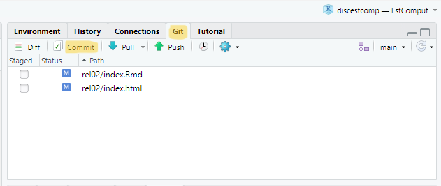

Commitando

[figure not shown]

Commitando e dando push

### 2.5.2 Via Terminal

- Para que as alterações sejam enviadas de maneira mais rápida e eficiente, esta poderá ser feita através do terminal, localizado no segundo quadrante e deverá seguir os seguintes passos:

```markdown
$ git add .

$ git commit -m "escrever a informação que foi alterada"

$ git push
```

## 2.6 Repositório sendo disponibilizado via online

- O projeto no repositório poderá ser acessado via internet.
- Para isso, o arquivo rmd deverá ser compilado salvo com o nome específico de `index` e compilado em HTML, clicando em *Knit to HTML* no primeiro quadrante.
- Feito isso, deverá acessar a página do GitHub e clicar em *Settings* > *Pages* > em *Source*, escolha a opção *main root* > *Save*
- Dessa forma, após alguns minutos, a página estará disponível.

[figure not shown]

Criando repositório online